# Test - Hypothetical Hummocky Low Relief

Steffi LaZerte

2017-08-25

# Details

2.22 min to run

#### Original Dem (Relief)

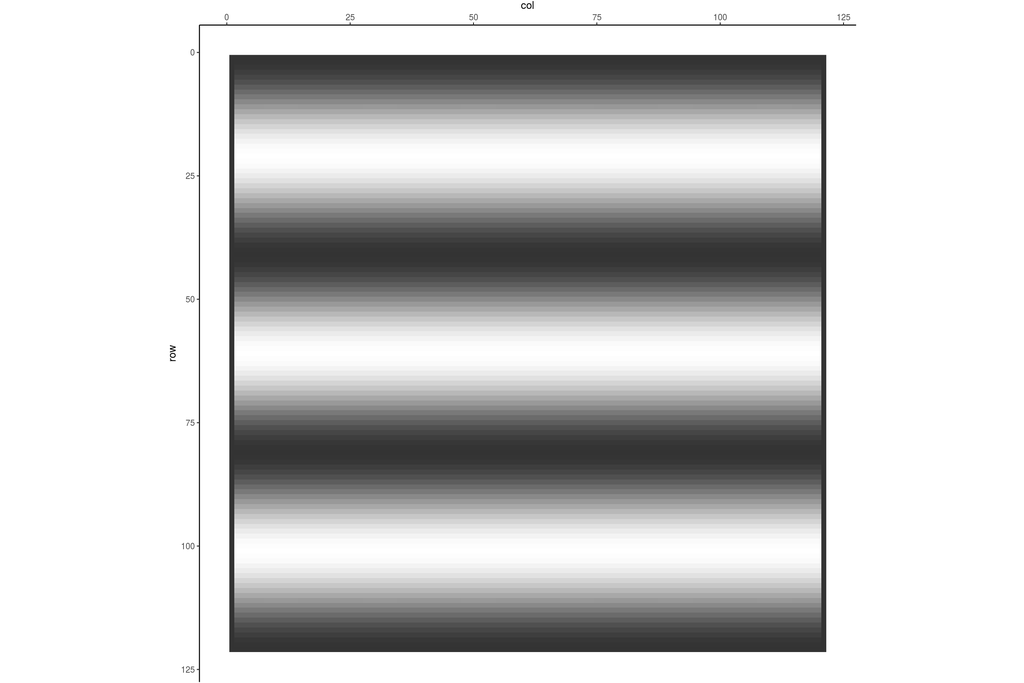

#### Original Dem (Elevation)

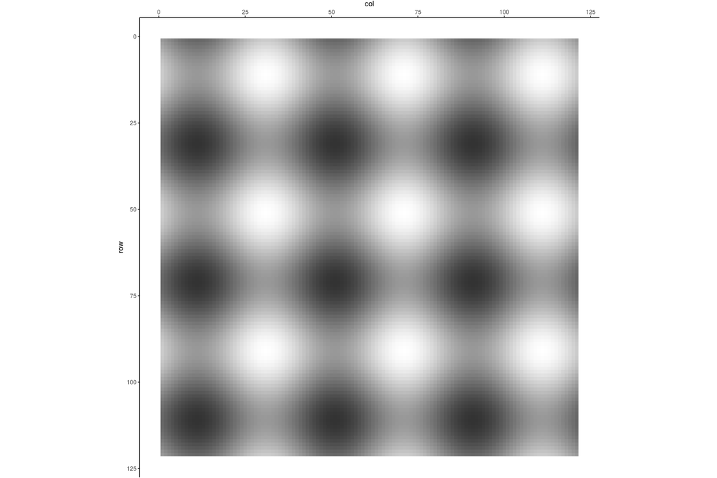

# Visual Comparison

## Original vs. New Local Shed assignment

- These are the local sheds (shedno) after amalgamating the small ones
- Sheds are identical

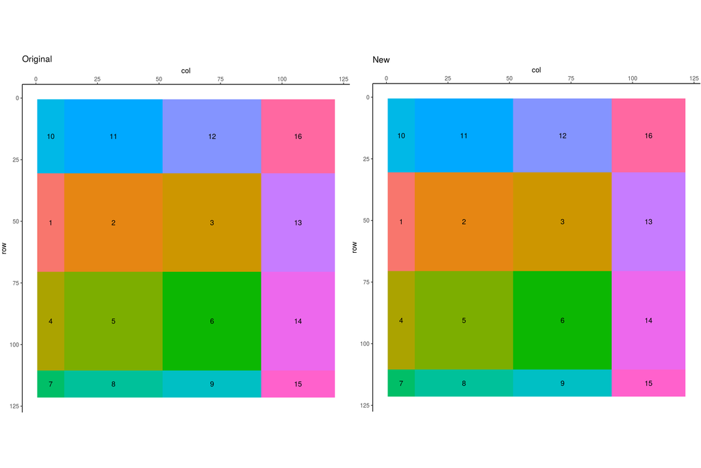

## Original vs. New Pond Shed assignment

- These are the pond sheds, which reflect how sheds combined during the second pit removal process
- Sheds are identical (numbered the same too, however the underlying sheds have differnet numbering)

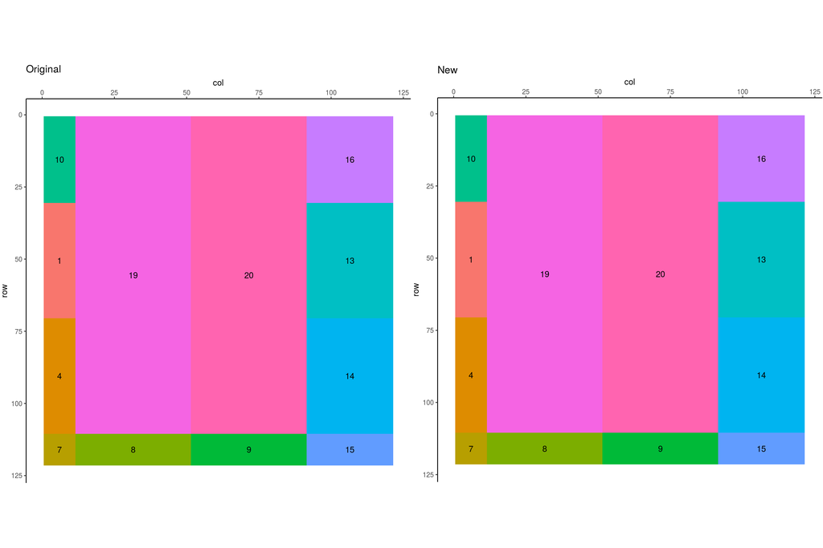

# Numeric Comparison

## Compare pit stats

**Original Pit data**

|  | ShedNo | Edge | Final | EndPit | ShedArea | PitRow | PitCol | PitRec | PitElev | PourElev | PreVol | PitVol | Varatio | PitArea | DrainsTo | NextPit | Becomes | Removed | InRow | InCol | InRec | InElev | OutRow | OutCol | OutRec | OutElev | Stage | Visited |
| --- | --- | --- | --- | --- | --- | --- | --- | --- | --- | --- | --- | --- | --- | --- | --- | --- | --- | --- | --- | --- | --- | --- | --- | --- | --- | --- | --- | --- |
| 1 | 1 | False | True | 1 | 440 | 51 | 1 | 6051 | 99.5 | 100 | 0 | 20.619 | 46.86 | 111 | 2 | 19 | 1 | False | 51 | 11 | 6061 | 100 | 51 | 12 | 6062 | 99.9938 | 1 | True |
| 2 | 4 | False | True | 4 | 440 | 91 | 1 | 10891 | 99.5 | 100 | 0 | 20.619 | 46.86 | 111 | 5 | 19 | 4 | False | 91 | 11 | 10901 | 100 | 91 | 12 | 10902 | 99.9938 | 1 | True |
| 3 | 7 | False | True | 7 | 121 | 121 | 1 | 14521 | 100 | 100.5 | 0 | 5.919 | 48.92 | 38 | 4 | 4 | 7 | False | 111 | 1 | 13311 | 100.5 | 110 | 1 | 13190 | 100.4938 | 1 | True |
| 4 | 8 | False | True | 8 | 440 | 121 | 31 | 14551 | 99.5 | 100 | 0 | 20.619 | 46.86 | 121 | 5 | 19 | 8 | False | 111 | 31 | 13341 | 100 | 110 | 31 | 13220 | 99.9938 | 1 | True |
| 5 | 9 | False | True | 9 | 440 | 121 | 71 | 14591 | 99.5 | 100 | 0 | 20.619 | 46.86 | 121 | 6 | 20 | 9 | False | 111 | 71 | 13381 | 100 | 110 | 71 | 13260 | 99.9938 | 1 | True |
| 6 | 10 | False | True | 10 | 330 | 11 | 1 | 1211 | 99.5 | 100 | 0 | 20.619 | 62.48 | 111 | 11 | 19 | 10 | False | 11 | 11 | 1221 | 100 | 11 | 12 | 1222 | 99.9938 | 1 | True |
| 7 | 13 | False | True | 13 | 1200 | 51 | 111 | 6161 | 99 | 100 | 0 | 309.626 | 258.02 | 739 | 16 | 16 | 13 | False | 31 | 111 | 3741 | 100 | 30 | 111 | 3620 | 99.9938 | 1 | True |
| 8 | 14 | False | True | 14 | 1200 | 91 | 111 | 11001 | 99 | 100 | 0 | 309.626 | 258.02 | 739 | 13 | 13 | 14 | False | 71 | 111 | 8581 | 100 | 70 | 111 | 8460 | 99.9938 | 1 | True |
| 9 | 15 | False | True | 15 | 330 | 121 | 111 | 14631 | 99.5 | 100 | 0 | 20.619 | 62.48 | 121 | 14 | 14 | 15 | False | 111 | 111 | 13421 | 100 | 110 | 111 | 13300 | 99.9938 | 1 | True |
| 10 | 16 | False | True | 16 | 900 | 11 | 111 | 1321 | 99 | 100 | 0 | 295.354 | 328.17 | 598 | 13 | 13 | 16 | False | 30 | 111 | 3620 | 99.9938 | 31 | 111 | 3741 | 100 | 1 | True |

[output cut: 2 more lines]

**New Pit data**

|  | ShedNo | Edge | Final | EndPit | ShedArea | PitRow | PitCol | PitRec | PitElev | PourElev | PreVol | PitVol | Varatio | PitArea | DrainsTo | NextPit | Becomes | Removed | InRow | InCol | InRec | InElev | OutRow | OutCol | OutRec | OutElev | Stage | Visited |
| --- | --- | --- | --- | --- | --- | --- | --- | --- | --- | --- | --- | --- | --- | --- | --- | --- | --- | --- | --- | --- | --- | --- | --- | --- | --- | --- | --- | --- |
| 1 | 1 | True | True | 1 | 440 | 51 | 1 | 6051 | 99.5 | 100 | 0 | 20.619 | 46.86 | 102 | 17 | 19 | 1 | False | 51 | 11 | 6061 | 100 | 51 | 12 | 6062 | 99.994 | 0 | False |
| 2 | 4 | True | True | 4 | 440 | 91 | 1 | 10891 | 99.5 | 100 | 0 | 20.619 | 46.86 | 102 | 5 | 19 | 4 | False | 91 | 11 | 10901 | 100 | 91 | 12 | 10902 | 99.994 | 0 | False |
| 3 | 7 | True | True | 7 | 121 | 121 | 1 | 14521 | 100 | 100.5 | 0 | 5.919 | 48.92 | 37 | 4 | 4 | 7 | False | 111 | 1 | 13311 | 100.5 | 110 | 1 | 13190 | 100.494 | 0 | False |
| 4 | 8 | True | True | 8 | 440 | 121 | 31 | 14551 | 99.5 | 100 | 0 | 20.619 | 46.86 | 101 | 5 | 19 | 8 | False | 111 | 31 | 13341 | 100 | 110 | 31 | 13220 | 99.994 | 0 | False |
| 5 | 9 | True | True | 9 | 440 | 121 | 71 | 14591 | 99.5 | 100 | 0 | 20.619 | 46.86 | 101 | 6 | 20 | 9 | False | 111 | 71 | 13381 | 100 | 110 | 71 | 13260 | 99.994 | 0 | False |
| 6 | 10 | True | True | 10 | 330 | 11 | 1 | 1211 | 99.5 | 100 | 0 | 20.619 | 62.48 | 103 | 17 | 19 | 10 | False | 11 | 11 | 1221 | 100 | 11 | 12 | 1222 | 99.994 | 0 | False |
| 7 | 13 | True | True | 13 | 1200 | 51 | 111 | 6161 | 99 | 100 | 0 | 309.626 | 258.02 | 681 | 16 | 16 | 13 | False | 31 | 111 | 3741 | 100 | 30 | 111 | 3620 | 99.994 | 0 | False |
| 8 | 14 | True | True | 14 | 1200 | 91 | 111 | 11001 | 99 | 100 | 0 | 309.626 | 258.02 | 681 | 13 | 13 | 14 | False | 71 | 111 | 8581 | 100 | 70 | 111 | 8460 | 99.994 | 0 | False |
| 9 | 15 | True | True | 15 | 330 | 121 | 111 | 14631 | 99.5 | 100 | 0 | 20.619 | 62.48 | 101 | 14 | 14 | 15 | False | 111 | 111 | 13421 | 100 | 110 | 111 | 13300 | 99.994 | 0 | False |
| 10 | 16 | True | True | 16 | 900 | 11 | 111 | 1321 | 99 | 100 | 0 | 295.354 | 328.17 | 598 | 18 | 20 | 16 | False | 11 | 92 | 1302 | 99.9938 | 11 | 91 | 1301 | 100 | 0 | False |

[output cut: 2 more lines]

**Differences**

```r
c <- compare(pit, orig_pit)
```

```
## Not all Edge the same
```

```
## Not all EndPit the same
```

```
## Not all PreVol the same
```

```
## Not all PitVol the same
```

```
## Varatio not the same, but within 5
```

```
## Pit area not the same, but within 3 cells
```

```
## Not all DrainsTo the same
```

```
## Not all NextPit the same
```

```
## In Rec not all the same, but all within 1 cell
```

```
## Out Rec not all the same, but all within 1 cell
```

```
## Out elev not all the same, but within 0.01
```

```
## Not all Stage the same
```

```
## Not all Visited the same
```

- For some reason original end pit is different for last two pits:

```r
pit[c$EndPit, ] %>% select(ShedNo, EndPit, ShedArea, PitArea, Becomes)
```

```
##    ShedNo EndPit ShedArea PitArea Becomes
## 11     19     19     4400    2207      19
## 12     20     20     4400    2207      20
```

```r
orig_pit[c$EndPit, ] %>% select(ShedNo, EndPit, ShedArea, PitArea, Becomes)
```

```
##    ShedNo EndPit ShedArea PitArea Becomes
## 11     19     20     4400    2396      19
## 12     20     18     4400    2396      20
```

- Pit area off, probably likely due to tie breaking which is more of a problem when the watershed is uniform

```r
pit[c$PitArea, ] %>% select(ShedNo, EndPit, ShedArea, PitArea, PitVol, Varatio,
    Becomes)
```

```
##    ShedNo EndPit ShedArea PitArea  PitVol Varatio Becomes
## 1       1      1      440     102  20.619   46.86       1
## 2       4      4      440     102  20.619   46.86       4
## 3       7      7      121      37   5.919   48.92       7
## 4       8      8      440     101  20.619   46.86       8
## 5       9      9      440     101  20.619   46.86       9
## 6      10     10      330     103  20.619   62.48      10
## 7      13     13     1200     681 309.626  258.02      13
## 8      14     14     1200     681 309.626  258.02      14
## 9      15     15      330     101  20.619   62.48      15
## 11     19     19     4400    2207 957.409  217.59      19
## 12     20     20     4400    2207 957.409  217.59      20
```

```r
orig_pit[c$PitArea, ] %>% select(ShedNo, EndPit, ShedArea, PitArea, PitVol,
    Varatio, Becomes)
```

```
##    ShedNo EndPit ShedArea PitArea  PitVol Varatio Becomes
## 1       1      1      440     111  20.619   46.86       1
## 2       4      4      440     111  20.619   46.86       4
## 3       7      7      121      38   5.919   48.92       7
## 4       8      8      440     121  20.619   46.86       8
## 5       9      9      440     121  20.619   46.86       9
## 6      10     10      330     111  20.619   62.48      10
## 7      13     13     1200     739 309.626  258.02      13
## 8      14     14     1200     739 309.626  258.02      14
## 9      15     15      330     121  20.619   62.48      15
## 11     19     20     4400    2396 956.409  217.37      19
## 12     20     18     4400    2396 956.409  217.37      20
```

- PreVol/Stage/Visited not used by LITAP

## Compare pond stats

**Original Pond data**

|  | ShedNo | Edge | Final | EndPit | ShedArea | PitRow | PitCol | PitRec | PitElev | PourElev | PreVol | PitVol | Varatio | PitArea | DrainsTo | NextPit | Becomes | Removed | InRow | InCol | InRec | InElev | OutRow | OutCol | OutRec | OutElev | Stage | Visited |
| --- | --- | --- | --- | --- | --- | --- | --- | --- | --- | --- | --- | --- | --- | --- | --- | --- | --- | --- | --- | --- | --- | --- | --- | --- | --- | --- | --- | --- |
| 1 | 1 | True | True | 0 | 440 | 51 | 1 | 6051 | 99.5 | 100 | 0 | 20.619 | 46.86 | 111 | 2 | 20 | 0 | False | 51 | 11 | 6061 | 100 | 51 | 12 | 6062 | 99.9938 | 1 | False |
| 2 | 2 | False | False | 0 | 1600 | 51 | 31 | 6081 | 99 | 100 | 0 | 323.892 | 202.43 | 839 | 11 | 20 | 19 | True | 31 | 31 | 3661 | 100 | 30 | 31 | 3540 | 99.9938 | 1 | False |
| 3 | 3 | False | False | 0 | 1600 | 51 | 71 | 6121 | 99 | 100 | 0 | 323.892 | 202.43 | 839 | 12 | 18 | 17 | True | 31 | 71 | 3701 | 100 | 30 | 71 | 3580 | 99.9938 | 1 | False |
| 4 | 4 | True | True | 0 | 440 | 91 | 1 | 10891 | 99.5 | 100 | 0 | 20.619 | 46.86 | 111 | 5 | 20 | 0 | False | 91 | 11 | 10901 | 100 | 91 | 12 | 10902 | 99.9938 | 1 | False |
| 5 | 5 | False | False | 0 | 1600 | 91 | 31 | 10921 | 99 | 100 | 0 | 323.892 | 202.43 | 839 | 2 | 19 | 19 | True | 71 | 31 | 8501 | 100 | 70 | 31 | 8380 | 99.9938 | 1 | False |
| 6 | 6 | False | False | 0 | 1600 | 91 | 71 | 10961 | 99 | 100 | 0 | 323.892 | 202.43 | 839 | 3 | 17 | 17 | True | 71 | 71 | 8541 | 100 | 70 | 71 | 8420 | 99.9938 | 1 | False |
| 7 | 7 | True | True | 0 | 121 | 121 | 1 | 14521 | 100 | 100.5 | 0 | 5.919 | 48.92 | 38 | 4 | 4 | 0 | False | 111 | 1 | 13311 | 100.5 | 110 | 1 | 13190 | 100.4938 | 1 | True |
| 8 | 8 | True | True | 0 | 440 | 121 | 31 | 14551 | 99.5 | 100 | 0 | 20.619 | 46.86 | 121 | 5 | 20 | 0 | False | 111 | 31 | 13341 | 100 | 110 | 31 | 13220 | 99.9938 | 1 | False |
| 9 | 9 | True | True | 0 | 440 | 121 | 71 | 14591 | 99.5 | 100 | 0 | 20.619 | 46.86 | 121 | 6 | 18 | 0 | False | 111 | 71 | 13381 | 100 | 110 | 71 | 13260 | 99.9938 | 1 | False |
| 10 | 10 | True | True | 0 | 330 | 11 | 1 | 1211 | 99.5 | 100 | 0 | 20.619 | 62.48 | 111 | 11 | 20 | 0 | False | 11 | 11 | 1221 | 100 | 11 | 12 | 1222 | 99.9938 | 1 | False |

[output cut: 10 more lines]

**New Pond data**

|  | ShedNo | Edge | Final | EndPit | ShedArea | PitRow | PitCol | PitRec | PitElev | PourElev | PreVol | PitVol | Varatio | PitArea | DrainsTo | NextPit | Becomes | Removed | InRow | InCol | InRec | InElev | OutRow | OutCol | OutRec | OutElev | Stage | Visited |
| --- | --- | --- | --- | --- | --- | --- | --- | --- | --- | --- | --- | --- | --- | --- | --- | --- | --- | --- | --- | --- | --- | --- | --- | --- | --- | --- | --- | --- |
| 1 | 2 | False | False | 0 | 1600 | 51 | 31 | 6081 | 99 | 100 | 0 | 323.892 | 202.43 | 762 | 11 | 11 | 17 | True | 31 | 31 | 3661 | 100 | 30 | 31 | 3540 | 99.994 | 0 | False |
| 2 | 3 | False | False | 0 | 1600 | 51 | 71 | 6121 | 99 | 100 | 0 | 323.892 | 202.43 | 762 | 12 | 12 | 18 | True | 31 | 71 | 3701 | 100 | 30 | 71 | 3580 | 99.994 | 0 | False |
| 3 | 5 | False | False | 0 | 1600 | 91 | 31 | 10921 | 99 | 100 | 0 | 323.892 | 202.43 | 762 | 2 | 2 | 19 | True | 71 | 31 | 8501 | 100 | 70 | 31 | 8380 | 99.994 | 0 | False |
| 4 | 6 | False | False | 0 | 1600 | 91 | 71 | 10961 | 99 | 100 | 0 | 323.892 | 202.43 | 762 | 3 | 3 | 20 | True | 71 | 71 | 8541 | 100 | 70 | 71 | 8420 | 99.994 | 0 | False |
| 5 | 11 | True | False | 0 | 1200 | 11 | 31 | 1241 | 99 | 100 | 0 | 309.626 | 258.02 | 685 | 12 | 12 | 17 | True | 11 | 51 | 1261 | 100 | 11 | 52 | 1262 | 99.994 | 0 | False |
| 6 | 12 | True | False | 0 | 1200 | 11 | 71 | 1281 | 99 | 100 | 0 | 309.626 | 258.02 | 685 | 16 | 16 | 18 | True | 11 | 91 | 1301 | 100 | 11 | 92 | 1302 | 99.994 | 0 | False |
| 7 | 13 | True | True | 0 | 1200 | 51 | 111 | 6161 | 99 | 100 | 0 | 309.626 | 258.02 | 681 | 16 | 16 | 0 | False | 31 | 111 | 3741 | 100 | 30 | 111 | 3620 | 99.994 | 0 | False |
| 8 | 14 | True | True | 0 | 1200 | 91 | 111 | 11001 | 99 | 100 | 0 | 309.626 | 258.02 | 681 | 13 | 13 | 0 | False | 71 | 111 | 8581 | 100 | 70 | 111 | 8460 | 99.994 | 0 | False |
| 9 | 16 | True | True | 0 | 900 | 11 | 111 | 1321 | 99 | 100 | 0 | 295.354 | 328.17 | 598 | 12 | 20 | 0 | False | 11 | 92 | 1302 | 99.9938 | 11 | 91 | 1301 | 100 | 0 | False |
| 10 | 1 | True | True | 0 | 440 | 51 | 1 | 6051 | 99.5 | 100 | 0 | 20.619 | 46.86 | 102 | 2 | 19 | 0 | False | 51 | 11 | 6061 | 100 | 51 | 12 | 6062 | 99.994 | 0 | False |

[output cut: 10 more lines]

Cells are so regular that tie breaking caused different flows paths between the two programs

For example, in the original file, watershed 16 drains to 13 (south), in LITAP watershed 16 drains to 12 (west)

There is no difference between the pour points, so it would just be a matter of which one was visited first.

```r
pond %>% filter(ShedNo == 16) %>% select(ShedNo, PitRec, PourElev, DrainsTo,
    OutElev)
```

```
##   ShedNo PitRec PourElev DrainsTo OutElev
## 1     16   1321      100       12     100
```

```r
orig_pond %>% filter(ShedNo == 16) %>% select(ShedNo, PitRec, PourElev, DrainsTo,
    OutElev)
```

```
##   ShedNo PitRec PourElev DrainsTo OutElev
## 1     16   1321      100       13     100
```

However the end product is the same (see pit files above)

```r
pond <- pond %>% arrange(ShedNo)
orig_pond <- orig_pond %>% arrange(ShedNo)
```

## Compare fill stats

We know the watersheds have different numbering, so first need to renumber all to match

```r
fill <- shedno_update2(fill)
orig_fill <- shedno_update2(orig_fill)
```

**Original Fill data**

|  | ShedNo | Edge | Final | ShedArea | PitRow | PitCol | PitRec | PitElev | PourElev | PreVol | PitVol | Varatio | PitArea | NextPit | Removed | InRow | InCol | InRec | InElev | OutRow | OutCol | OutRec | OutElev | Stage | Visited | Becomes | DrainsTo | EndPit |
| --- | --- | --- | --- | --- | --- | --- | --- | --- | --- | --- | --- | --- | --- | --- | --- | --- | --- | --- | --- | --- | --- | --- | --- | --- | --- | --- | --- | --- |
| 1 | 1 | False | False | 1600 | 51 | 31 | 6081 | 99 | 100 | 0 | 323.892 | 202.43 | 839 | 11 | True | 31 | 31 | 3661 | 100 | 30 | 31 | 3540 | 99.9938 | 1 | False | 7 | 9 | 6 |
| 2 | 9 | True | False | 1200 | 11 | 31 | 1241 | 99 | 100 | 0 | 309.626 | 258.02 | 719 | 12 | True | 11 | 51 | 1261 | 100 | 11 | 52 | 1262 | 99.9938 | 1 | True | 7 | 10 | 6 |
| 3 | 2 | False | False | 1600 | 51 | 71 | 6121 | 99 | 100 | 0 | 323.892 | 202.43 | 839 | 12 | True | 31 | 71 | 3701 | 100 | 30 | 71 | 3580 | 99.9938 | 1 | False | 8 | 10 | 8 |
| 4 | 10 | True | False | 1200 | 11 | 71 | 1281 | 99 | 100 | 0 | 309.626 | 258.02 | 719 | 16 | True | 11 | 91 | 1301 | 100 | 11 | 92 | 1302 | 99.9938 | 1 | True | 8 | 13 | 8 |
| 5 | 3 | False | False | 1600 | 91 | 31 | 10921 | 99 | 100 | 0 | 323.892 | 202.43 | 839 | 17 | True | 71 | 31 | 8501 | 100 | 70 | 31 | 8380 | 99.9938 | 1 | False | 5 | 1 | 6 |
| 6 | 7 | True | False | 2800 | 11 | 31 | 1241 | 99 | 100 | 633.517 | 633.517 | 226.26 | 1558 | 18 | True | 11 | 51 | 1261 | 100 | 11 | 52 | 1262 | 99.9938 | 0 | True | 5 | 10 | 6 |
| 7 | 4 | False | False | 1600 | 91 | 71 | 10961 | 99 | 100 | 0 | 323.892 | 202.43 | 839 | 18 | True | 71 | 71 | 8541 | 100 | 70 | 71 | 8420 | 99.9938 | 1 | False | 6 | 2 | 8 |
| 8 | 8 | True | False | 2800 | 11 | 71 | 1281 | 99 | 100 | 633.517 | 633.517 | 226.26 | 1558 | 16 | True | 11 | 91 | 1301 | 100 | 11 | 92 | 1302 | 99.9938 | 0 | True | 6 | 13 | 8 |
| 9 | 14 | True | True | 440 | 51 | 1 | 6051 | 99.5 | 100 | 0 | 20.619 | 46.86 | 111 | 19 | False | 51 | 11 | 6061 | 100 | 51 | 12 | 6062 | 99.9938 | 1 | True | 14 | 1 | 14 |
| 10 | 15 | True | True | 440 | 91 | 1 | 10891 | 99.5 | 100 | 0 | 20.619 | 46.86 | 111 | 19 | False | 91 | 11 | 10901 | 100 | 91 | 12 | 10902 | 99.9938 | 1 | True | 15 | 3 | 15 |

[output cut: 10 more lines]

**New Fill data**

|  | ShedNo | Edge | Final | ShedArea | PitRow | PitCol | PitRec | PitElev | PourElev | PreVol | PitVol | Varatio | PitArea | NextPit | Removed | InRow | InCol | InRec | InElev | OutRow | OutCol | OutRec | OutElev | Stage | Visited | Becomes | DrainsTo | EndPit |
| --- | --- | --- | --- | --- | --- | --- | --- | --- | --- | --- | --- | --- | --- | --- | --- | --- | --- | --- | --- | --- | --- | --- | --- | --- | --- | --- | --- | --- |
| 1 | 1 | False | False | 1600 | 51 | 31 | 6081 | 99 | 100 | 0 | 323.892 | 202.43 | 762 | 11 | False | 31 | 31 | 3661 | 100 | 30 | 31 | 3540 | 99.994 | 0 | False | 7 | 11 | 5 |
| 2 | 11 | True | False | 1200 | 11 | 31 | 1241 | 99 | 100 | 0 | 309.626 | 258.02 | 685 | 12 | False | 11 | 51 | 1261 | 100 | 11 | 52 | 1262 | 99.994 | 0 | False | 7 | 12 | 5 |
| 3 | 2 | False | False | 1600 | 51 | 71 | 6121 | 99 | 100 | 0 | 323.892 | 202.43 | 762 | 12 | False | 31 | 71 | 3701 | 100 | 30 | 71 | 3580 | 99.994 | 0 | False | 8 | 12 | 6 |
| 4 | 12 | True | False | 1200 | 11 | 71 | 1281 | 99 | 100 | 0 | 309.626 | 258.02 | 685 | 16 | False | 11 | 91 | 1301 | 100 | 11 | 92 | 1302 | 99.994 | 0 | False | 8 | 13 | 6 |
| 5 | 3 | False | False | 1600 | 91 | 31 | 10921 | 99 | 100 | 0 | 323.892 | 202.43 | 762 | 17 | False | 71 | 31 | 8501 | 100 | 70 | 31 | 8380 | 99.994 | 0 | False | 5 | 1 | 5 |
| 6 | 7 | True | False | 2800 | 11 | 31 | 1241 | 99 | 100 | 0 | 633.517 | 226.26 | 1446 | 18 | False | 11 | 51 | 1261 | 100 | 11 | 52 | 1262 | 99.994 | 0 | False | 5 | 12 | 5 |
| 7 | 4 | False | False | 1600 | 91 | 71 | 10961 | 99 | 100 | 0 | 323.892 | 202.43 | 762 | 18 | False | 71 | 71 | 8541 | 100 | 70 | 71 | 8420 | 99.994 | 0 | False | 6 | 2 | 6 |
| 8 | 8 | True | False | 2800 | 11 | 71 | 1281 | 99 | 100 | 0 | 633.517 | 226.26 | 1446 | 16 | False | 11 | 91 | 1301 | 100 | 11 | 92 | 1302 | 99.994 | 0 | False | 6 | 13 | 6 |
| 9 | 16 | True | True | 440 | 51 | 1 | 6051 | 99.5 | 100 | 0 | 20.619 | 46.86 | 102 | 19 | False | 51 | 11 | 6061 | 100 | 51 | 12 | 6062 | 99.994 | 0 | False | 16 | 7 | 16 |
| 10 | 17 | True | True | 440 | 91 | 1 | 10891 | 99.5 | 100 | 0 | 20.619 | 46.86 | 102 | 19 | False | 91 | 11 | 10901 | 100 | 91 | 12 | 10902 | 99.994 | 0 | False | 17 | 3 | 17 |

[output cut: 10 more lines]

- Order of pit filling is the same

**Differences**

```r
fill <- arrange(fill, ShedNo)
orig_fill <- arrange(orig_fill, ShedNo)
c <- compare(fill, orig_fill)
```

```
## Not all Final the same
```

```
## Pit Rec not all the same, but all within 1 cell
```

```
## Not all PreVol the same
```

```
## Not all PitVol the same
```

```
## Varatio not the same, but within 5
```

```
## Pit area not the same, but within 3 cells
```

```
## Not all NextPit the same
```

```
## Not all Removed the same
```

```
## In Rec not all the same, but all within 1 cell
```

```
## Out Rec not all the same, but all within 1 cell
```

```
## Out elev not all the same, but within 0.01
```

```
## Not all Stage the same
```

```
## Not all Visited the same
```

```
## Not all Becomes the same
```

```
## Not all DrainsTo the same
```

```
## Not all EndPit the same
```

## Inverted DEM

Black dots indicate pits, or, as this is inverted, peaks

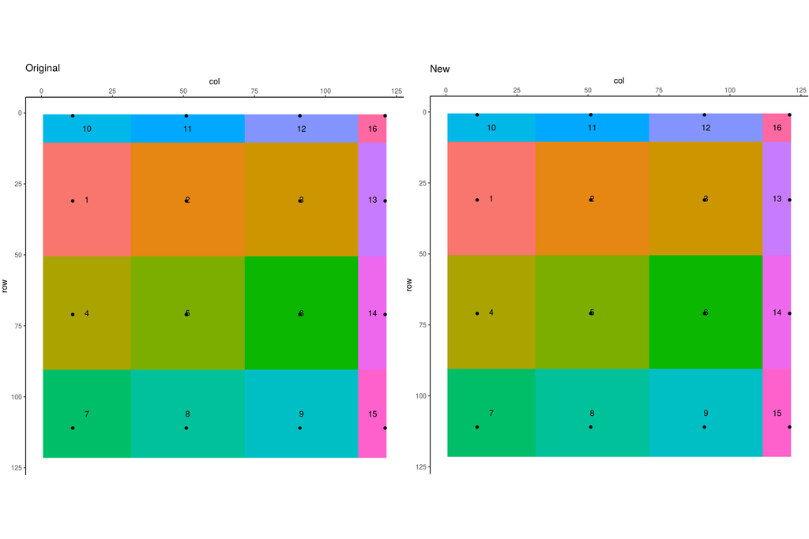

```r
c <- compare(ipit, orig_ipit)
```

```
## Not all Edge the same
```

```
## Pit area not the same, but within 3 cells
```

```
## Not all DrainsTo the same
```

```
## In Rec not all the same, but all within 1 cell
```

```
## Not all InElev the same
```

```
## Out Rec not all the same, but all within 1 cell
```

```
## Out elev not all the same, but within 0.01
```

- Pit areas off by a small amount
- small differences in exact pit location (off by one cell at most)
- Drains To not used by FlowMapR